Toggle Input Cells

# Californa API Analysis Examples

This IPython notebook is an example of using IPython and Ambry for analyzing Academic Performance Index scores for California, from 2000 to 2012. This data was extracted from the California Department of Education website and loaded into Ambry to create a single dataset that combines multiple years of data and harmonizes column names across the years. [An earlier version of this set](http://data.sandiegodata.org/dataset/cde_ca_gov-api-combined-429e-extract) can be downloaded from the San Diego Regional Data Library Data Repository, which also hosts the [documentation for the dataset](http://data.sandiegodata.org/storage/f/2013-11-05T211612/documentation.html).

In this example, we will show how to get datasets from an Ambry library and perform some analysis using Pandas.

## Getting Data With Ambry

Ambry is a data library and package management system that makes it much easier for analysts to get data to use in their analysis. In these first cells, we will get a library objectand look for the API dataset.

In this case, Ambry has been previously configured to connect to a remote Ambry library that hosts the dataset.

First we will construct the interactive library using ilibrary() and search for files that have 'api' in the name.

```python
import ambry
import pandas as pd
l = ambry.ilibrary()
l.find(name='api')
```

| SLR | d008001 | cde.ca.gov-api-orig-0.1.1 |
| --- | --- | --- |
| L | d007002 | cde.ca.gov-api-combined-0.1.2 |
| SLR | d007001 | cde.ca.gov-api-combined-0.1.1 |

The last line of the input cell, `l.find(name='api')` returns a list of records in a way that allows IPython to print it in HTML form. This is a frequently-used way to get more information about objects with using IPython Notebook.

The find command looks for all of the records of datasets in the local library and displays the ones that have 'api' in the name. The first column of the output tells us where the data lives. 'SLR' means that the data is on the local machine as a Source package, in the Local librayr, and also in the Remote library. The second column is the unique, versioned id number. The last two items are the same dataset, but one is a later version than the other.

Each of these datasets may be composed of multiple partitions, with each partition holding a part of a dataset, broken up by time, geographic location, or other factor. Now we will fetch one of the packages and look at what partitions are available.

```python
b =  l.get('cde.ca.gov-api-combined-api_base')
b
```

| **Identity** |  |
| --- | --- |
| Vid | d007002 |
| Sname | cde.ca.gov-api-combined |
| Vname | cde.ca.gov-api-combined-0.1.2 |
| Locations | L |
| **Source** |  |
| Db | /data/library/cde.ca.gov/api-combined-0.1.2.db |
| Created | 2014-03-24T05:49:02.347291 |
| Built | 2014-03-24T05:55:49.269265 |
| Build_Time | 397.12s |
| Prepared | 2014-03-24T05:49:11.899166 |
| Partitions | 2 |

When we asked for the dataset without a version number, Ambry selected the latest version and returned it. This object is also know as a "Bundle" since it provides the grouping for multiple partitions. On the last line we can see that this bundle has two partitions.

```python
b.partitions
```

| Id | Name | table |
| --- | --- | --- |
| p007001 | cde.ca.gov-api-combined-api_base | api_base |
| p007002 | cde.ca.gov-api-combined-api_growth | api_growth |

One partition in the bundle is for the base API scores, and the other is for year-to-year growth in the scores. Let's get the base partition and examine it. If you print out the `p` object, you'll get information about the partition, but we'll focus on the main table in the partition.

```python
p = l.get('cde.ca.gov-api-combined-api_base').partition
assert(p.identity.on.revision >= 2)
p.table
```

| Name | api_base |
| --- | --- |
| Id | t00701 |
| Vid | t00701002 |

| # | Name | Datatype | description |
| --- | --- | --- | --- |
| 1 | id | INTEGER |  |
| 2 | year | INTEGER | School year , from original dataset |
| 3 | cds | INTEGER64 | County/District/School code |
| 4 | stype | VARCHAR | Type: 1=Unified, 2=Elementary District, 3=9-12 High District, 4=7-12 High District, E=Elementary School, M=Middle School, H=High School |
| 5 | sname | VARCHAR | School Name |
| 6 | dname | VARCHAR | District Name |
| 7 | cname | VARCHAR | County Name |
| 8 | flag | INTEGER | Flag Values |
| 9 | api | INTEGER | [This Year] API (Base) |
| 10 | pct_test | INTEGER | Percentage of Students Tested |
| 11 | valid_num | INTEGER | Number of Students Included in the [This Year] Academic Performance Index (API) |
| 12 | st_rank | INTEGER | Statewide Rank (I=Invalid data, B=District or ASAM, C=Special Education School . ) |
| 13 | sum_rank | VARCHAR | Similar Schools Rank |
| 14 | gr_targ | INTEGER | [Next Year Range] API Growth Target (A=means the school or student group scored at or above the statewide performance target of 800 in [This Year], B=This is an LEA, C=means this is a special educatio… |
| 15 | api_targ | INTEGER | [Next Year] API Target (A=means the school or student group scored at or above the statewide performance target of 800 in [This Year], B=This is an LEA, C=means this is a special education school.) |
| 16 | aa_num | INTEGER | Number of Black or African Americans Included in API |
| 17 | aa_sig | VARCHAR | Black or African Americans Significant?(Yes/No) |
| 18 | aa_api | INTEGER | [This Year] Black or African American API (Base) |
| 19 | aa_gt | INTEGER | [Next Year Range] Black or African American student group Growth Target |
| 20 | aa_targ | INTEGER | [Next Year] Black or African American student group API Target |
| 21 | ai_num | INTEGER | Number of American Indian/Alaska Native Included in API |
| 22 | ai_sig | VARCHAR | American Indian/Alaska Native Significant?(Yes/No) |
| 23 | ai_api | INTEGER | [This Year] American Indian/Alaska Native API (Base) |
| 24 | ai_gt | INTEGER | [Next Year Range] American Indian/Alaska Native student group Growth Target |
| 25 | ai_targ | INTEGER | [Next Year] American Indian/Alaska Native student group API Target |
| 26 | as_num | INTEGER | Number of Asian Included in API |
| 27 | as_sig | VARCHAR | Asian Significant?(Yes/No) |
| 28 | as_api | INTEGER | [This Year] Asian API (Base) |
| 29 | as_gt | INTEGER | [Next Year Range] Asian student group Growth Target |
| 30 | as_targ | INTEGER | [Next Year] Asian student group API Target |

[output cut: 153 more lines]

Displaying the table presents information about the table and the whole table schema. Now we can use that schema to construct a query, load the data into a Pandas data frame and do some analysis.

## Analyzing Data

```python
q = """
SELECT
cds, year, api, valid,
aa_num, pct_aa,  aa_api,
wh_num,  pct_wh, wh_api,
hi_num,  pct_hi, hi_api,
as_num,  pct_as, as_api,
el
FROM api_base
---WHERE wh_sig = 'Yes' AND aa_sig = 'Yes'
"""

df = p.select(q).pandas
df.head()
```

|  | cds | year | api | valid | aa_num | pct_aa | aa_api | wh_num | pct_wh | wh_api | hi_num | pct_hi | hi_api | as_num | pct_as | as_api | el |
| --- | --- | --- | --- | --- | --- | --- | --- | --- | --- | --- | --- | --- | --- | --- | --- | --- | --- |
| 0 | 1611190130229 | 2000 | 731 | 1090 | 39 | 4 | NaN | 414 | 38 | 760 | 96 | 9 | NaN | 414 | 38 | 749 | 16 |
| 1 | 1611190132878 | 2000 | 622 | 840 | 160 | 23 | 528 | 191 | 23 | 734 | 92 | 11 | NaN | 195 | 21 | 642 | 18 |
| 2 | 1611196000004 | 2000 | 622 | 472 | 138 | 31 | 555 | 90 | 19 | 714 | 62 | 13 | NaN | 75 | 15 | 672 | 25 |
| 3 | 1611196090005 | 2000 | 774 | 272 | 16 | 7 | NaN | 61 | 24 | 781 | 21 | 7 | NaN | 104 | 38 | 813 | 26 |
| 4 | 1611196090013 | 2000 | 811 | 216 | 6 | 3 | NaN | 128 | 59 | 851 | 19 | 9 | NaN | 17 | 7 | NaN | 9 |

5 rows × 17 columns

Ambry datasets are stored in Sqlite, a complete SQL database system, so you can run standard SQL queries to extract data. If you don't want to use SQL, you can omit the query to get the whole dataset into Pandas, but this can consume a lot of memory.

Now that we've extracted some data, we'll convert the Pandas Dataframe into a Time-series panel so we can analyze school performance across multiple years.

```python
mldf = df.set_index(['cds','year'])
pan = mldf.to_panel() # Convert to a time-series panel
df.head()
```

|  | cds | year | api | valid | aa_num | pct_aa | aa_api | wh_num | pct_wh | wh_api | hi_num | pct_hi | hi_api | as_num | pct_as | as_api | el |
| --- | --- | --- | --- | --- | --- | --- | --- | --- | --- | --- | --- | --- | --- | --- | --- | --- | --- |
| 0 | 1611190130229 | 2000 | 731 | 1090 | 39 | 4 | NaN | 414 | 38 | 760 | 96 | 9 | NaN | 414 | 38 | 749 | 16 |
| 1 | 1611190132878 | 2000 | 622 | 840 | 160 | 23 | 528 | 191 | 23 | 734 | 92 | 11 | NaN | 195 | 21 | 642 | 18 |
| 2 | 1611196000004 | 2000 | 622 | 472 | 138 | 31 | 555 | 90 | 19 | 714 | 62 | 13 | NaN | 75 | 15 | 672 | 25 |
| 3 | 1611196090005 | 2000 | 774 | 272 | 16 | 7 | NaN | 61 | 24 | 781 | 21 | 7 | NaN | 104 | 38 | 813 | 26 |
| 4 | 1611196090013 | 2000 | 811 | 216 | 6 | 3 | NaN | 128 | 59 | 851 | 19 | 9 | NaN | 17 | 7 | NaN | 9 |

5 rows × 17 columns

Using Pandas for data analysis is a bit beyond the scope of this introduction, and panels can be complicated. FOr this tutorial, is is most important to know that a panel works like a 3-dimentional structure, where two of the dimensions are CDS -- the school identification number -- and the year. The third is the data columns. Panels provide a convient way to analyze time series.

In particular, with the object `pan`, we can extract a single column. For instance `pan['pct_wh']` extracts a 2-dimensional table of percentages of White test takers, with one entry for each school and each year. Then `pan['pct_wh'].mean()` will compute the mean value for each year across all of the schools. ( If we had set the indices the other way, with `df.set_index(['year','cds'])` then `mean()` would calculate the mean value for each school across the years.

Finally, we will perform this calculation for the four largest racial categories and combine them into a single table.

```python
racial_pcts = pd.concat([pan['pct_wh'].mean(), pan['pct_aa'].mean(),pan['pct_hi'].mean(), pan['pct_as'].mean()], axis=1)
racial_pcts.columns = ['pct_wh', 'pct_aa', 'pct_hi', 'pct_as']
racial_pcts
```

| year | pct_wh | pct_aa | pct_hi | pct_as |
| --- | --- | --- | --- | --- |
| 2000 | 41.583866 | 8.068314 | 37.180228 | 7.684532 |
| 2001 | 40.582148 | 7.956793 | 38.696600 | 7.823513 |
| 2002 | 39.264540 | 7.874262 | 39.876774 | 7.470670 |
| 2003 | 38.175535 | 7.853156 | 40.768910 | 7.799948 |
| 2004 | 36.548480 | 8.058513 | 42.218551 | 7.542833 |
| 2005 | 37.419843 | 7.689846 | 41.728833 | 6.885074 |
| 2006 | 36.110113 | 7.740394 | 43.053814 | 6.883961 |
| 2007 | 34.854257 | 7.597130 | 44.374363 | 6.861903 |
| 2008 | 34.124119 | 7.575547 | 44.982481 | 6.921672 |
| 2009 | 32.502490 | 7.012359 | 46.723022 | 6.697657 |
| 2010 | 31.377451 | 6.844895 | 47.487976 | 6.658898 |
| 2011 | 30.811612 | 6.757984 | 48.482093 | 6.739062 |
| 2012 | 30.071060 | 6.527281 | 49.373825 | 6.849862 |

13 rows × 4 columns

Now, for a plot of the numbers.

# Creating Plots

Now that we have a table of data, the next thing to do is plot it.

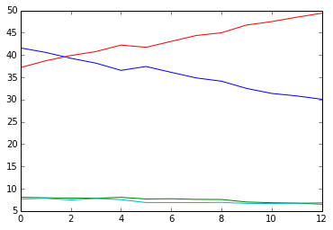

```python
plot(racial_pcts)
```

That was really easy, but not pretty. Getting a proper legend takes a bit more work.

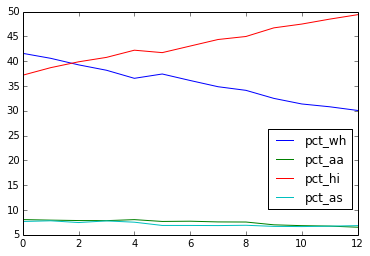

```python
fig = figure()
ax = subplot(111)

for col in list(racial_pcts.columns.values):
    ax.plot(racial_pcts[col], label=col)

ax.legend(loc='best', bbox_to_anchor=(1, 0.5))

show()
```

Now we can do the same analysis with the racial decomposition of the API scores.

```python
racial_api = pd.concat([pan['wh_api'].mean(), pan['aa_api'].mean(),pan['hi_api'].mean(), pan['as_api'].mean(),  pan['api'].mean()], axis=1)
racial_api.columns = ['wh_api', 'aa_api', 'hi_api', 'as_api', 'api']
racial_api
```

| year | wh_api | aa_api | hi_api | as_api | api |
| --- | --- | --- | --- | --- | --- |
| 2000 | 754.833398 | 539.138191 | 561.320104 | 763.738829 | 664.013330 |
| 2001 | 764.221646 | 558.045637 | 590.500859 | 778.712006 | 678.221455 |
| 2002 | 755.863559 | 583.440522 | 606.420455 | 790.185051 | 672.521166 |
| 2003 | 773.843319 | 614.223096 | 640.589239 | 819.339151 | 698.575149 |
| 2004 | 782.908093 | 627.501956 | 653.971558 | 827.729469 | 704.875387 |
| 2005 | 802.223397 | 644.298651 | 674.301652 | 845.039953 | 719.537087 |
| 2006 | 811.552061 | 651.378954 | 687.832747 | 857.502990 | 731.497423 |
| 2007 | 816.539268 | 662.507138 | 698.492086 | 862.568250 | 737.797575 |
| 2008 | 823.953580 | 677.312845 | 712.537803 | 874.356673 | 748.117746 |
| 2009 | 838.553227 | 687.460584 | 728.301985 | 886.549235 | 760.024318 |
| 2010 | 824.281111 | 730.420517 | 742.022761 | 881.878955 | 771.152960 |
| 2011 | 830.330179 | 738.412236 | 751.336661 | 887.924102 | 778.314244 |
| 2012 | 838.764326 | 748.795690 | 762.093897 | 894.560418 | 787.529222 |

13 rows × 5 columns

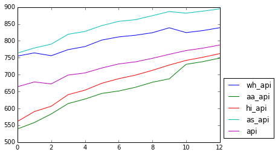

```python
fig = figure()
ax = subplot(111)

for col in list(racial_api.columns.values):
    ax.plot(racial_api[col], label=col)

ax.legend(loc='best', bbox_to_anchor=(1, 0.5))

show()
```

## More Complex Analysis

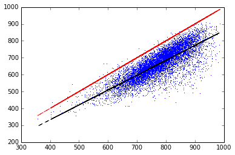

```python
# We need to run the query again to add the significance criteria.
q = """
SELECT
cds, year, api, valid,
aa_num, pct_aa,  aa_api,
wh_num,  pct_wh, wh_api,
hi_num,  pct_hi, hi_api,
as_num,  pct_as, as_api,
el
FROM api_base
WHERE wh_sig = 'Yes' AND aa_sig = 'Yes'
"""

df = p.select(q).pandas
df.head()

x = df.wh_api
y = df.aa_api
fit = polyfit(x,y,1)
fit_fn = poly1d(fit) # fit_fn is now a function which takes in x and returns an estimate for y

plot(x,y, 'b,', x, fit_fn(x), '--k', x,x, '--r')
```

```python
aa_better = df[df.aa_api > df.wh_api]
aa_better.count()
```

```
cds       39
year      39
api       39
valid     34
aa_num    39
pct_aa    36
aa_api    39
wh_num    39
pct_wh    36
wh_api    39
hi_num    39
pct_hi    36
hi_api    37
as_num    39
pct_as    36
as_api    10
el        18
dtype: int64
```